# Overview of Publications and Citations

Anders Aasted Isaksen

2025-08-07

## Metrics

Number of publications: 10

Number of first authorships: 4

Number of last authorships: 1

Total number of citations: 75

H-index: 4

## Citation history

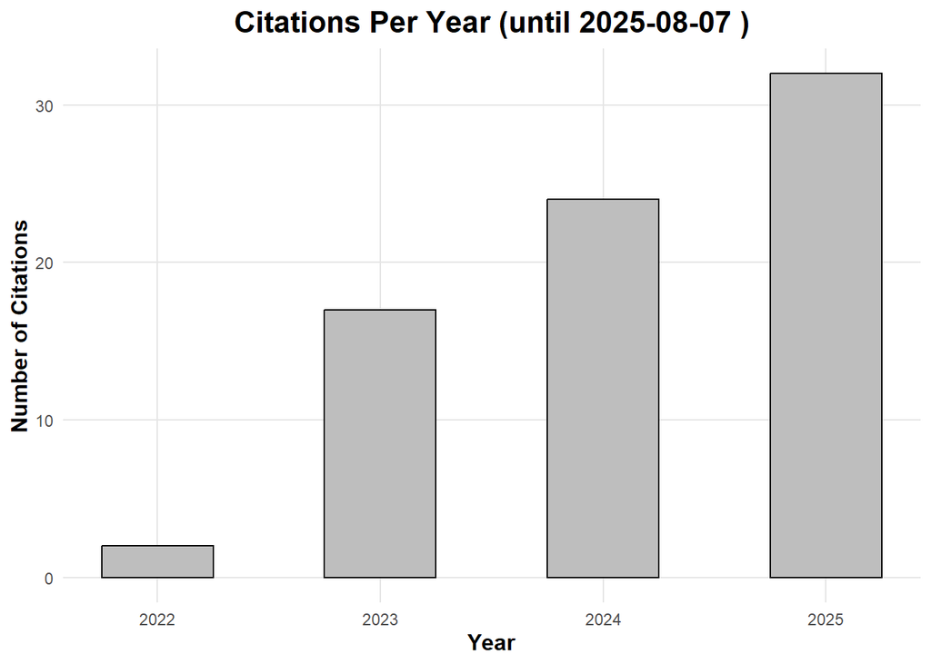

## Publication List

Thomsen, HB., Li, LY., **Isaksen, AA.**, Lebiecka-Johansen, B., Bour, C., & … (2025). Racial disparities in continuous glucose monitoring-based 60-min glucose predictions among people with type 1 diabetes. *PLOS Digital Health*. 4 (6), e0000918

Schaarup, JR., **Isaksen, AA.**, Norman, K., Bjerg, L., & Hulman, A. (2025). Trust in large language model-based solutions in healthcare among people with and without diabetes: a cross-sectional survey from the Health in Central Denmark cohort. *medRxiv*. 2025.02. 24.25322734

**Isaksen, AA.**, Schaarup, JR., Bjerg, L., & Hulman, A. (2025). Changes in public perception of AI in healthcare after exposure to ChatGPT. *medRxiv*. 2025.01. 23.25321048

Li, LY., **Isaksen, AA.**, Lebiecka-Johansen, B., Funck, K., Thambawita, V., & … (2024). Prediction of cardiovascular markers and diseases using retinal fundus images and deep learning: a systematic scoping review. *European Heart Journal-Digital Health*. 5 (6), 660-669

**Isaksen, AA.**, Sandbæk, A., & Bjerg, L. (2023). Validation of register-based diabetes classifiers in Danish data. *Clinical Epidemiology*. 569-581

**Isaksen, AA.**, Sandbæk, A., Skriver, MV., & Bjerg, L. (2023). Glucose‐lowering drug use in migrants and native Danes with type 2 diabetes: Disparities in combination therapy and drug types. *Diabetes, Obesity and Metabolism*. 25 (11), 3307-3316

**Isaksen, AA.**, Sandbæk, A., Skriver, MV., Andersen, GS., & Bjerg, L. (2023). Guideline-level monitoring, biomarker levels and pharmacological treatment in migrants and native Danes with type 2 diabetes: Population-wide analyses. *PLOS Global Public Health*. 3 (10), e0001277

Funck, KL., Bjerg, L., **Isaksen, AA.**, Sandbæk, A., & Grove, EL. (2022). Gender disparities in time-to-initiation of cardioprotective glucose-lowering drugs in patients with type 2 diabetes and cardiovascular disease: a Danish nationwide cohort study. *Cardiovascular Diabetology*. 21 (1), 279

Bjerg, L., Dalsgaard, EM., Norman, K., **Isaksen, AA.**, & Sandbæk, A. (2022). Cohort profile: Health in Central Denmark (HICD) cohort-a register-based questionnaire survey on diabetes and related complications in the Central Denmark Region. *BMJ open*. 12 (7), e060410

Johnston, L., Juel, HB., Lengger, B., Witte, DR., Chatwin, H., Christiansen, MR., & **Isaksen, AA.** (2021). r-cubed: Guiding the overwhelmed scientist from random wrangling to Reproducible Research in R. *Journal of Open Source Education*. 4 (44)